# Assignment 10: Predictive Modeling - Part 1

*How to do it?*:

- Open the Rmarkdown file of this assignment (link) in Rstudio.
- Right under each **question**, insert a code chunk (you can use the hotkey `Ctrl + Alt + I` to add a code chunk) and code the solution for the question.
- `Knit` the rmarkdown file (hotkey: `Ctrl + Alt + K`) to export an html.
- Publish the html file to your Githiub Page.

*Submission*: Submit the link on Github of the assignment to Canvas

1. Use the `Adult Census Income` dataset. We will predict the income (whether or not it is more than 50k or not) of an adult. Import the dataset. Partition the data into 80% training and 20% testing.

```r
library(gganimate)
library(ggplot2)
library(tidyverse)
library(knitr)
library(tidyverse)
setwd("C:/Users/student/Downloads")
df =  read_csv('adult_census.csv')
df <- df %>% rename(target=income)
df <- df %>% select(-workclass, -occupation, -native.country, -hours.per.week, -capital.loss, -education.num, -fnlwgt)
df = drop_na(df)
df <- df %>%
  mutate(target = as.factor(target),
         marital.status = as.factor(marital.status),
         education = as.factor(education),
         race = as.factor(race),
         relationship = as.factor(relationship),
         sex = as.factor(sex)
         )

#install.packages("caret")
library(caret)
set.seed(100)
splitIndex <- createDataPartition(df$target, p = .80,
                                  list = FALSE)
df_train <- df[ splitIndex,]
df_test <- df[-splitIndex,]

head(df)
```

```
## # A tibble: 6 × 8
##     age education    marital.status relationship race  sex   capital.gain target
##   <dbl> <fct>        <fct>          <fct>        <fct> <fct>        <dbl> <fct>
## 1    90 HS-grad      Widowed        Not-in-fami… White Fema…            0 <=50K
## 2    82 HS-grad      Widowed        Not-in-fami… White Fema…            0 <=50K
## 3    66 Some-college Widowed        Unmarried    Black Fema…            0 <=50K
## 4    54 7th-8th      Divorced       Unmarried    White Fema…            0 <=50K
## 5    41 Some-college Separated      Own-child    White Fema…            0 <=50K
## 6    34 HS-grad      Divorced       Unmarried    White Fema…            0 <=50K
```

2. Practice Decision Tree. Do the follows:
- Use `rpart` package, create a decision tree with maximum depth of 3.

```r
library(rpart) #load the rpart package
# Create a tree
tree_model <- rpart(target ~ ., data = df_train,
                 control = rpart.control(maxdepth = 3))
head(df)
```

```
## # A tibble: 6 × 8
##     age education    marital.status relationship race  sex   capital.gain target
##   <dbl> <fct>        <fct>          <fct>        <fct> <fct>        <dbl> <fct>
## 1    90 HS-grad      Widowed        Not-in-fami… White Fema…            0 <=50K
## 2    82 HS-grad      Widowed        Not-in-fami… White Fema…            0 <=50K
## 3    66 Some-college Widowed        Unmarried    Black Fema…            0 <=50K
## 4    54 7th-8th      Divorced       Unmarried    White Fema…            0 <=50K
## 5    41 Some-college Separated      Own-child    White Fema…            0 <=50K
## 6    34 HS-grad      Divorced       Unmarried    White Fema…            0 <=50K
```

- Calculate the accuracy of the model on the testing data. Notice that the positive outcome here is not `1` but `>50K` or `<50K`.

```r
#predict on testing data
pred <- predict(tree_model, df_test, type = "class")
#Evaluate the predictions
cm <- confusionMatrix(data = pred, reference = factor(df_test$target), positive = ">50K")
cm$overall[1]
```

```
## Accuracy
## 0.844441
```

- Plot the tree

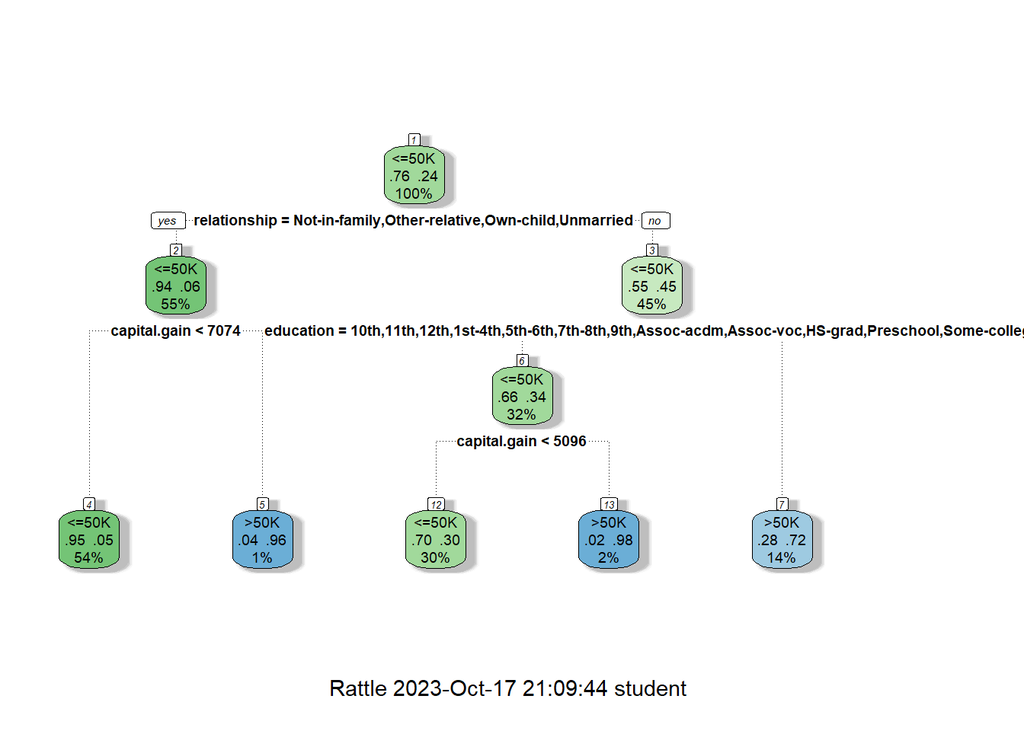

```r
#install.packages("rattle")
library(rattle)
fancyRpartPlot(tree_model)
```

```r
tree_model$variable.importance
```

```
##   relationship marital.status   capital.gain      education            sex
##    1946.414902    1915.249838     973.829799     852.020646     600.710733
##            age           race
##     439.278999       4.579067
```